# BEAM Project: Antigen Affinity and Clonal Analysis

Author

Foo

Published

May 9, 2025

### 0.1 Data Processing Pipeline

The following flowchart describes the computational pipeline used for loading multimodal single-cell data, processing BCR clone files, binning antigen expression, and plotting histogram comparisons across clone categories.

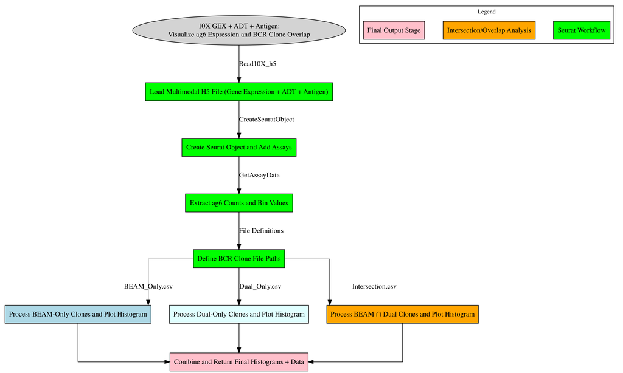

Pipeline

### 0.2 BEAM Light Chain Versus Antigen Affinity

These figures display the number and frequency of light chain clones (based on `Clean_Clone_ID`) detected in each ag6 expression bin. The data highlight whether certain light chain clones are enriched in high-binding cells.

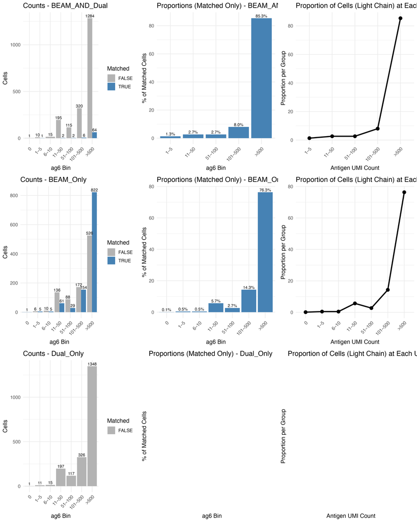

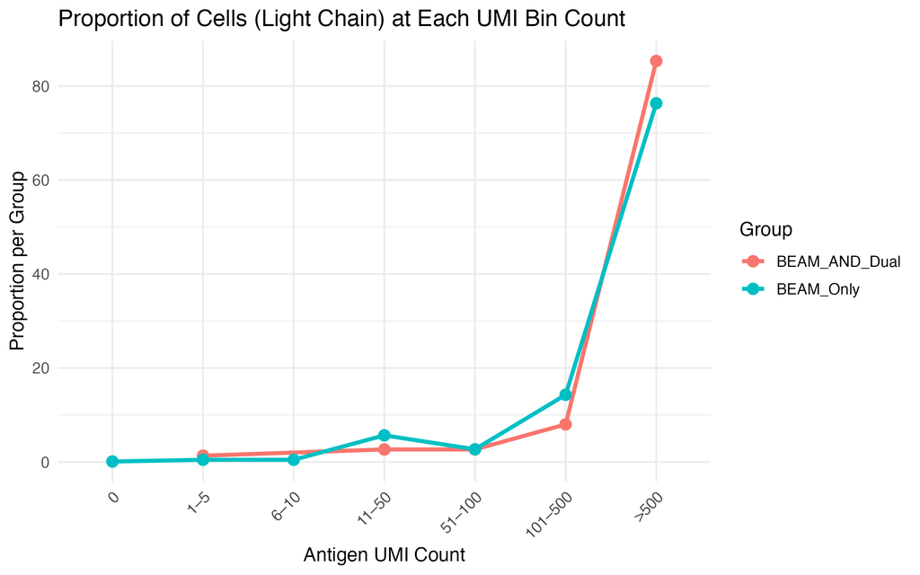

### 0.3 BEAM Heavy Chain Versus Antigen Affinity

These figures provide a similar analysis for heavy chain clones. By comparing trends in heavy chain clonal frequency versus antigen binding, we can determine whether high-affinity cells preferentially express certain heavy chain clones.

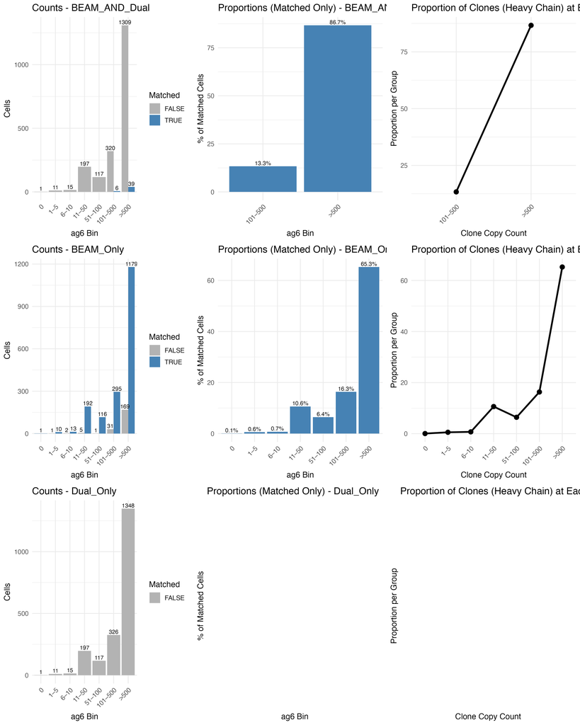

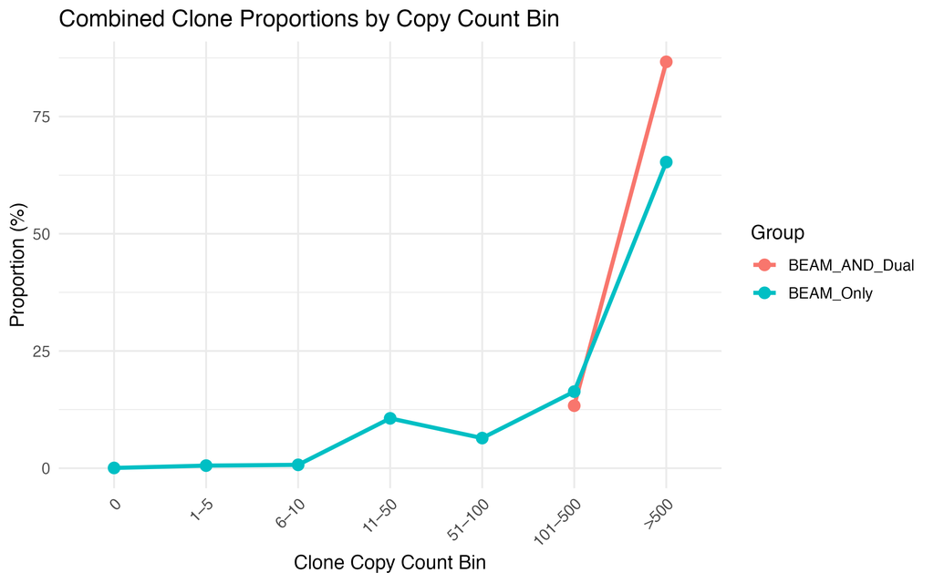

### 0.4 Summary and Interpretation

Light chain clones showed a strong enrichment in bins with higher ag6 expression, suggesting that many high-affinity cells share common light chain features.

These observations suggest that clonal expansion is associated with antigen affinity. Selection for clones—especially those with strong light chain contributions—that bind more strongly to antigen.

### 0.5 Appendix: Optional Code Reveal

```r
# Example usage of plotting function
process_bcr_and_plot("./intersection_sets/intersection_1_BEAM_Positive.csv", label = "BEAM Light Chain")
```